# Techniki Wizualizacji Danych, praca domowa nr 3

Maciej Borkowski

18 listopada 2022

Zadaniem projektowym jest przeprowadzenie eksperymentu badającego, czy określone problemy z czytaniem danych wciąż występują.

## Opis eksperymentu

Postanowiłem zbadać, jak prezentacja danych na wykresie kołowym wpływa na poprawność ich odbioru oraz jaki wpływ na odbiór ma użycie koloru.  
Do badania przygotowałem 8 wykresów kołowych - 4 czarno-białe i 4 kolorowe, które parami mają identyczne dane wejściowe. Danymi wejściowymi jest wektor odpowiednio 4, 5, 5 i 6 liczb sumujących się do 100 i dzielący koło na odpowiadającą liczbę obszarów. Do celów badania ankietowego, tak, aby badany nie zdawał sobie sprawy z podobieństwa wykresów, wykresy zostały poobracane i umieszczone w ankiecie w losowej kolejności. Należy zaznaczyć, że kolory zostały dobrane losowo i nie zależą w żaden sposób od wielkości obszarów.  
Zadaniem badanego było wskazanie poprawnej kolejności, powierzchniowo od najmniejszego do największego, oznaczonych literami pól na wykresie, gdzie żaden z wykresów nie posiada dwóch pól o identycznych powierzchniach.  
Poniżej prezentuję przygotowane wykresy, dwie pierwsze kolumny zawierają wykresy użyte w badaniu ankietowym, trzecia kolumna prezentuje dane wejściowe umieszczone na wykresie punktowym w celach poglądowych.

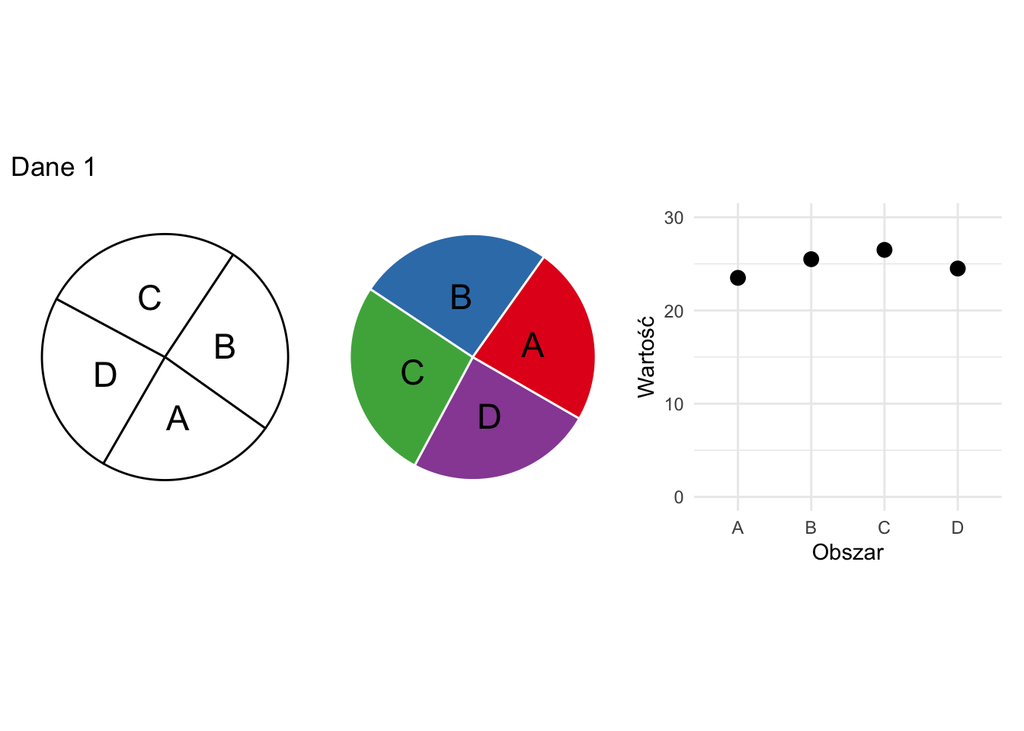

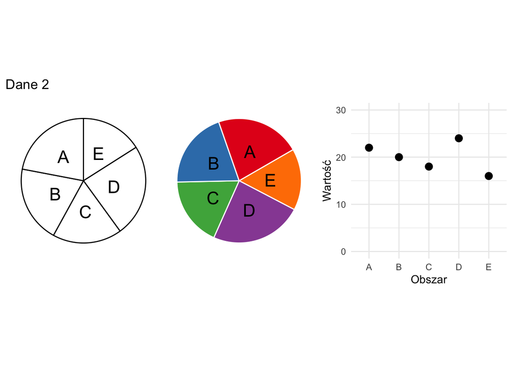

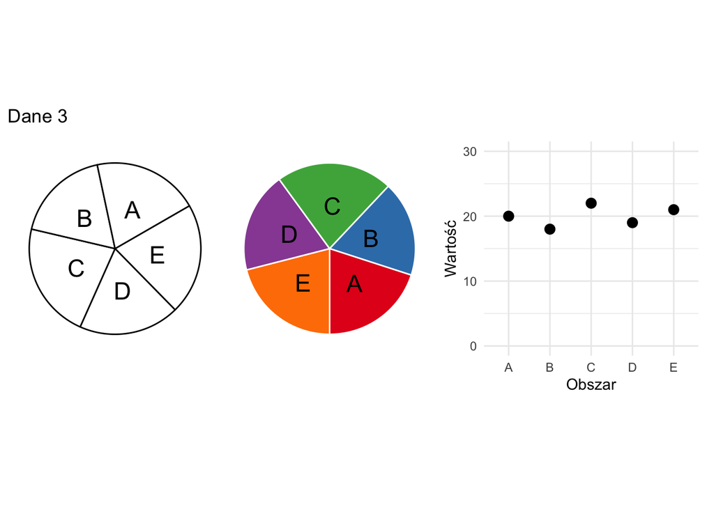

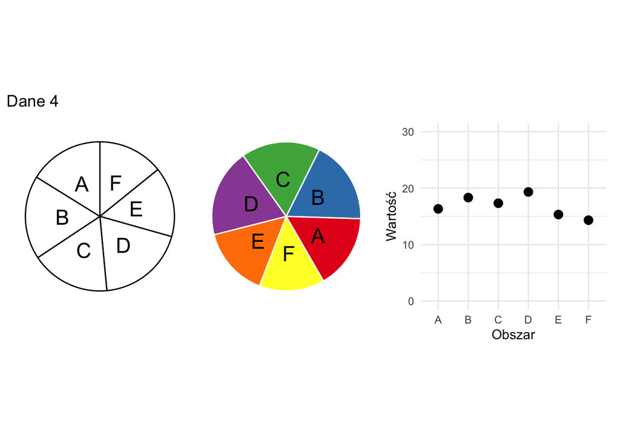

Należy zaznaczyć, że w badaniu ankietowym wykresy kołowe były odpowiednio powiększone, tak aby umożliwić poprawny odczyt.

## Wyniki i wnioski

W badaniu ankietowym udział wzięło 38 osób. Wyniki pokazują, że badanym częściej udało się wskazać poprawną kolejność w przypadku wykresów z drugim zestawem danych, gdzie rozrzut jest większy w porównaniu do pozostałych danych. Widzimy, że liczba obszarów nie miała dla badanych znaczenia.  
W ostatecznym rozrachunku można wyróżnić dwa wnioski:  
- Użycie koloru nie wpłynęło skuteczność odczytywania danych. Należy zaznaczyć, że przeprowadzający badanie nie ma szerokiej wiedzy co do stosowania kolorów na wykresach kołowych, więc zostały one dobrane losowo, a badanie tego czynnika wyniknęło z ciekawości autora.  
- Skuteczność tego sposobu prezentacji danych jest niska, wynosi bowiem około 41,8%. Badający nie przeprowadzał próby kontrolnej zakładającej przedstawienie danych na wykresach punktowych i zdaje sobie sprawę z małego rozrzutu użytych danych, jednak zakłada z dużą dozą pewności, że skuteczność przy odczycie danych z wykresów punktowych byłaby znacząco wyższa (można powiedzieć, że różnice w położeniu punktów widać wprost).

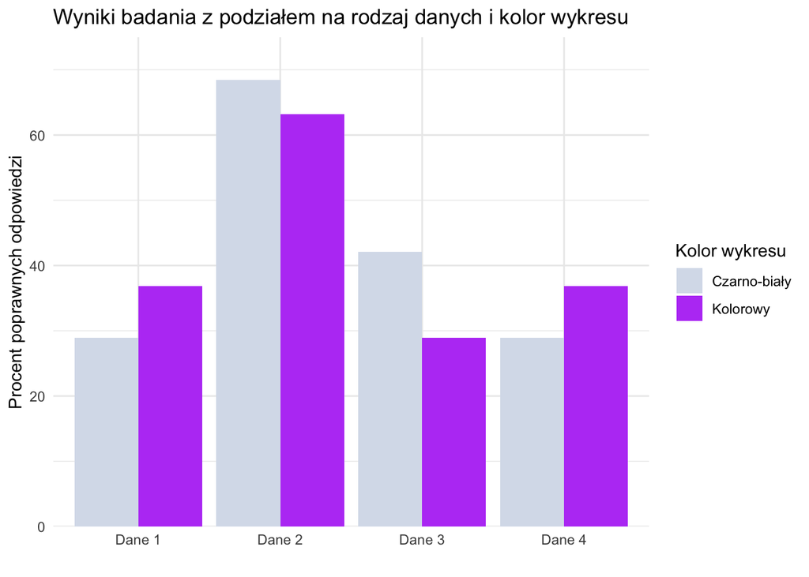

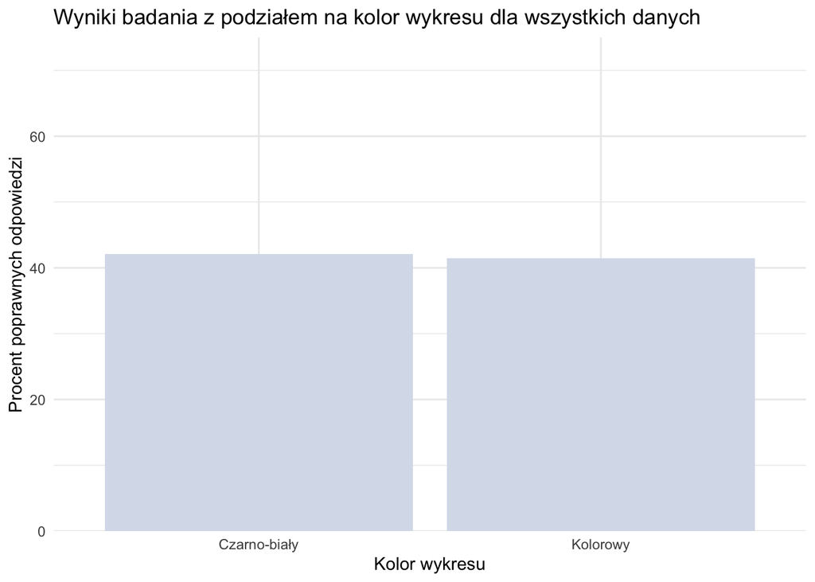

Przedstawiam ankietę użytą do przeprowadzenia badania: [Link](https://forms.office.com/r/rRMVTQqHUc)